# Risk Factor Analysis

## Outcome Variable

**Outcome Variable:** haz

## Predictor Variables

**Intervention Variable:** fage

**Adjustment Set:**

- arm
- W_mage
- meducyrs
- feducyrs
- W_mhtcm
- W_mwtkg
- W_mbmi
- W_fhtcm
- single
- brthmon
- delta_W_mage
- delta_meducyrs
- delta_feducyrs
- delta_W_mhtcm
- delta_W_mwtkg
- delta_W_mbmi
- delta_W_fhtcm
- delta_single
- delta_brthmon

## Stratifying Variables

The analysis was stratified on these variable(s):

- agecat
- studyid
- country

## Data Summary

| agecat | studyid | country | fage | n_cell | n |
| --- | --- | --- | --- | --- | --- |
| Birth | ki0047075b-MAL-ED | BANGLADESH | >=38 | 67 | 145 |
| Birth | ki0047075b-MAL-ED | BANGLADESH | <32 | 27 | 145 |
| Birth | ki0047075b-MAL-ED | BANGLADESH | [32-38) | 51 | 145 |
| Birth | ki0047075b-MAL-ED | BRAZIL | >=38 | 27 | 68 |
| Birth | ki0047075b-MAL-ED | BRAZIL | <32 | 16 | 68 |
| Birth | ki0047075b-MAL-ED | BRAZIL | [32-38) | 25 | 68 |
| Birth | ki0047075b-MAL-ED | INDIA | >=38 | 27 | 131 |
| Birth | ki0047075b-MAL-ED | INDIA | <32 | 44 | 131 |
| Birth | ki0047075b-MAL-ED | INDIA | [32-38) | 60 | 131 |
| Birth | ki0047075b-MAL-ED | NEPAL | >=38 | 13 | 61 |
| Birth | ki0047075b-MAL-ED | NEPAL | <32 | 9 | 61 |
| Birth | ki0047075b-MAL-ED | NEPAL | [32-38) | 39 | 61 |
| Birth | ki0047075b-MAL-ED | PERU | >=38 | 27 | 80 |
| Birth | ki0047075b-MAL-ED | PERU | <32 | 27 | 80 |
| Birth | ki0047075b-MAL-ED | PERU | [32-38) | 26 | 80 |
| Birth | ki0047075b-MAL-ED | SOUTH AFRICA | >=38 | 53 | 76 |
| Birth | ki0047075b-MAL-ED | SOUTH AFRICA | <32 | 8 | 76 |
| Birth | ki0047075b-MAL-ED | SOUTH AFRICA | [32-38) | 15 | 76 |
| Birth | ki0047075b-MAL-ED | TANZANIA, UNITED REPUBLIC OF | >=38 | 21 | 46 |
| Birth | ki0047075b-MAL-ED | TANZANIA, UNITED REPUBLIC OF | <32 | 6 | 46 |
| Birth | ki0047075b-MAL-ED | TANZANIA, UNITED REPUBLIC OF | [32-38) | 19 | 46 |
| Birth | ki1000304b-SAS-CompFeed | INDIA | >=38 | 4 | 187 |
| Birth | ki1000304b-SAS-CompFeed | INDIA | <32 | 152 | 187 |
| Birth | ki1000304b-SAS-CompFeed | INDIA | [32-38) | 31 | 187 |
| Birth | ki1119695-PROBIT | BELARUS | >=38 | 606 | 13390 |
| Birth | ki1119695-PROBIT | BELARUS | <32 | 10724 | 13390 |
| Birth | ki1119695-PROBIT | BELARUS | [32-38) | 2060 | 13390 |
| Birth | ki1135781-COHORTS | GUATEMALA | >=38 | 245 | 823 |
| Birth | ki1135781-COHORTS | GUATEMALA | <32 | 380 | 823 |
| Birth | ki1135781-COHORTS | GUATEMALA | [32-38) | 198 | 823 |

[output cut: 75 more lines]

The following strata were considered:

- agecat: 24 months, studyid: ki0047075b-MAL-ED, country: BANGLADESH
- agecat: 24 months, studyid: ki0047075b-MAL-ED, country: BRAZIL
- agecat: 24 months, studyid: ki0047075b-MAL-ED, country: INDIA
- agecat: 24 months, studyid: ki0047075b-MAL-ED, country: NEPAL
- agecat: 24 months, studyid: ki0047075b-MAL-ED, country: PERU
- agecat: 24 months, studyid: ki0047075b-MAL-ED, country: SOUTH AFRICA
- agecat: 24 months, studyid: ki0047075b-MAL-ED, country: TANZANIA, UNITED REPUBLIC OF
- agecat: 24 months, studyid: ki1119695-PROBIT, country: BELARUS
- agecat: 24 months, studyid: ki1135781-COHORTS, country: GUATEMALA
- agecat: 24 months, studyid: ki1135781-COHORTS, country: PHILIPPINES
- agecat: 24 months, studyid: ki1148112-LCNI-5, country: MALAWI
- agecat: 6 months, studyid: ki0047075b-MAL-ED, country: BANGLADESH
- agecat: 6 months, studyid: ki0047075b-MAL-ED, country: BRAZIL
- agecat: 6 months, studyid: ki0047075b-MAL-ED, country: INDIA
- agecat: 6 months, studyid: ki0047075b-MAL-ED, country: NEPAL
- agecat: 6 months, studyid: ki0047075b-MAL-ED, country: PERU
- agecat: 6 months, studyid: ki0047075b-MAL-ED, country: SOUTH AFRICA
- agecat: 6 months, studyid: ki0047075b-MAL-ED, country: TANZANIA, UNITED REPUBLIC OF
- agecat: 6 months, studyid: ki1000304b-SAS-CompFeed, country: INDIA
- agecat: 6 months, studyid: ki1000304b-SAS-FoodSuppl, country: INDIA
- agecat: 6 months, studyid: ki1119695-PROBIT, country: BELARUS
- agecat: 6 months, studyid: ki1135781-COHORTS, country: GUATEMALA
- agecat: 6 months, studyid: ki1135781-COHORTS, country: PHILIPPINES
- agecat: 6 months, studyid: ki1148112-LCNI-5, country: MALAWI
- agecat: Birth, studyid: ki0047075b-MAL-ED, country: BANGLADESH
- agecat: Birth, studyid: ki0047075b-MAL-ED, country: BRAZIL
- agecat: Birth, studyid: ki0047075b-MAL-ED, country: INDIA
- agecat: Birth, studyid: ki0047075b-MAL-ED, country: NEPAL
- agecat: Birth, studyid: ki0047075b-MAL-ED, country: PERU
- agecat: Birth, studyid: ki0047075b-MAL-ED, country: SOUTH AFRICA
- agecat: Birth, studyid: ki0047075b-MAL-ED, country: TANZANIA, UNITED REPUBLIC OF
- agecat: Birth, studyid: ki1000304b-SAS-CompFeed, country: INDIA
- agecat: Birth, studyid: ki1119695-PROBIT, country: BELARUS
- agecat: Birth, studyid: ki1135781-COHORTS, country: GUATEMALA
- agecat: Birth, studyid: ki1135781-COHORTS, country: PHILIPPINES

### Dropped Strata

Some strata were dropped due to rare outcomes:

- agecat: Birth, studyid: ki1000304b-SAS-CompFeed, country: INDIA

## Methods Detail

We’re interested in the causal parameters $E[Y_a]$ for all values of $a \in \mathcal{A}$. These parameters represent the mean outcome if, possibly contrary to fact, we intervened to set all units to have $A=a$. Under the randomization and positivity assumptions, these are identified by the statistical parameters $\psi_a=E_W[E_{Y|A,W}(Y|A=a,W)]$. In addition, we’re interested in the mean of $Y$, $E[Y]$ under no intervention (the observed mean). We will estimate these parameters by using SuperLearner to fit the relevant likelihood factors – $E_{Y|A,W}(Y|A=a,W)$ and $p(A=a|W)$, and then updating our likelihood fit using a joint TMLE.

For unadjusted analyses ($W=\{\}$), initial likelihoods were estimated using Lrnr_glm to estimate the simple $E(Y|A)$ and Lrnr_mean to estimate $p(A)$. For adjusted analyses, a small library containing Lrnr_glmnet, Lrnr_xgboost, and Lrnr_mean was used.

Having estimated these parameters, we will then use the delta method to estimate relative risks and attributable risks relative to a prespecified baseline level of $A$.

# Results Detail

## Results Plots

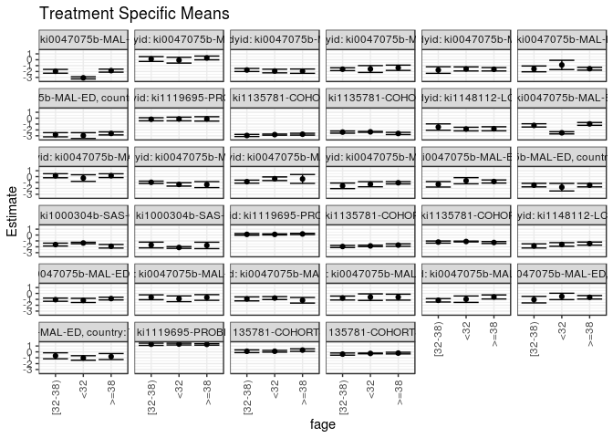

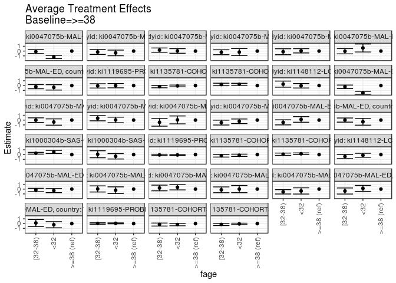

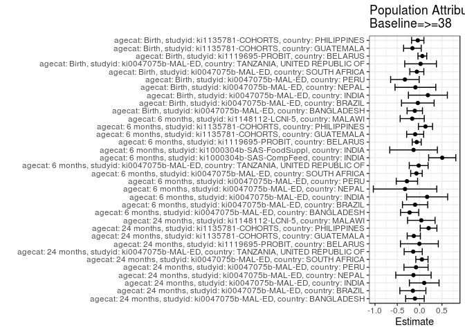

## Results Table

### Parameter: TSM

| agecat | studyid | country | intervention_level | baseline_level | estimate | ci_lower | ci_upper |
| --- | --- | --- | --- | --- | --- | --- | --- |
| Birth | ki0047075b-MAL-ED | BANGLADESH | >=38 | NA | -0.8697050 | -1.1034373 | -0.6359727 |
| Birth | ki0047075b-MAL-ED | BANGLADESH | <32 | NA | -1.1828990 | -1.5351713 | -0.8306267 |
| Birth | ki0047075b-MAL-ED | BANGLADESH | [32-38) | NA | -1.0583423 | -1.3292398 | -0.7874449 |
| Birth | ki0047075b-MAL-ED | BRAZIL | >=38 | NA | -0.6834917 | -1.1635193 | -0.2034641 |
| Birth | ki0047075b-MAL-ED | BRAZIL | <32 | NA | -0.9053637 | -1.3917193 | -0.4190082 |
| Birth | ki0047075b-MAL-ED | BRAZIL | [32-38) | NA | -0.6527561 | -1.0678342 | -0.2376779 |
| Birth | ki0047075b-MAL-ED | INDIA | >=38 | NA | -1.1574517 | -1.6368560 | -0.6780475 |
| Birth | ki0047075b-MAL-ED | INDIA | <32 | NA | -0.7831307 | -1.0349611 | -0.5313003 |
| Birth | ki0047075b-MAL-ED | INDIA | [32-38) | NA | -0.9249208 | -1.2628787 | -0.5869629 |
| Birth | ki0047075b-MAL-ED | NEPAL | >=38 | NA | -0.6300000 | -1.1327994 | -0.1272006 |
| Birth | ki0047075b-MAL-ED | NEPAL | <32 | NA | -0.6277778 | -1.1813379 | -0.0742177 |
| Birth | ki0047075b-MAL-ED | NEPAL | [32-38) | NA | -0.7782051 | -1.1107483 | -0.4456620 |
| Birth | ki0047075b-MAL-ED | PERU | >=38 | NA | -0.5958475 | -0.9405219 | -0.2511731 |
| Birth | ki0047075b-MAL-ED | PERU | <32 | NA | -0.9771333 | -1.5235629 | -0.4307036 |
| Birth | ki0047075b-MAL-ED | PERU | [32-38) | NA | -1.1624900 | -1.4528825 | -0.8720974 |
| Birth | ki0047075b-MAL-ED | SOUTH AFRICA | >=38 | NA | -0.6554717 | -0.9459850 | -0.3649584 |
| Birth | ki0047075b-MAL-ED | SOUTH AFRICA | <32 | NA | -0.5087500 | -1.0529159 | 0.0354159 |
| Birth | ki0047075b-MAL-ED | SOUTH AFRICA | [32-38) | NA | -1.0513333 | -1.6086365 | -0.4940302 |
| Birth | ki0047075b-MAL-ED | TANZANIA, UNITED REPUBLIC OF | >=38 | NA | -0.7961905 | -1.3086490 | -0.2837320 |
| Birth | ki0047075b-MAL-ED | TANZANIA, UNITED REPUBLIC OF | <32 | NA | -1.0350000 | -1.4136675 | -0.6563325 |
| Birth | ki0047075b-MAL-ED | TANZANIA, UNITED REPUBLIC OF | [32-38) | NA | -0.6684211 | -1.1811565 | -0.1556856 |
| Birth | ki1119695-PROBIT | BELARUS | >=38 | NA | 1.2730584 | 1.1471825 | 1.3989343 |
| Birth | ki1119695-PROBIT | BELARUS | <32 | NA | 1.3256385 | 1.1718748 | 1.4794021 |
| Birth | ki1119695-PROBIT | BELARUS | [32-38) | NA | 1.2957310 | 1.1055844 | 1.4858777 |
| Birth | ki1135781-COHORTS | GUATEMALA | >=38 | NA | 0.2990757 | 0.0889407 | 0.5092108 |
| Birth | ki1135781-COHORTS | GUATEMALA | <32 | NA | 0.1033534 | -0.0446257 | 0.2513325 |
| Birth | ki1135781-COHORTS | GUATEMALA | [32-38) | NA | 0.1024892 | -0.1282383 | 0.3332168 |
| Birth | ki1135781-COHORTS | PHILIPPINES | >=38 | NA | -0.2050937 | -0.3453570 | -0.0648303 |
| Birth | ki1135781-COHORTS | PHILIPPINES | <32 | NA | -0.2652312 | -0.3248462 | -0.2056163 |
| Birth | ki1135781-COHORTS | PHILIPPINES | [32-38) | NA | -0.3788030 | -0.5647972 | -0.1928088 |

[output cut: 72 more lines]

### Parameter: E(Y)

| agecat | studyid | country | intervention_level | baseline_level | estimate | ci_lower | ci_upper |
| --- | --- | --- | --- | --- | --- | --- | --- |
| Birth | ki0047075b-MAL-ED | BANGLADESH | NA | NA | -0.9778621 | -1.1318533 | -0.8238709 |
| Birth | ki0047075b-MAL-ED | BRAZIL | NA | NA | -0.7238235 | -0.9850427 | -0.4626043 |
| Birth | ki0047075b-MAL-ED | INDIA | NA | NA | -0.9720611 | -1.1477959 | -0.7963262 |
| Birth | ki0047075b-MAL-ED | NEPAL | NA | NA | -0.7244262 | -0.9767822 | -0.4720703 |
| Birth | ki0047075b-MAL-ED | PERU | NA | NA | -0.9256250 | -1.1260052 | -0.7252448 |
| Birth | ki0047075b-MAL-ED | SOUTH AFRICA | NA | NA | -0.7181579 | -0.9588306 | -0.4774852 |
| Birth | ki0047075b-MAL-ED | TANZANIA, UNITED REPUBLIC OF | NA | NA | -0.7745652 | -1.0958030 | -0.4533274 |
| Birth | ki1119695-PROBIT | BELARUS | NA | NA | 1.3342255 | 1.1742855 | 1.4941656 |
| Birth | ki1135781-COHORTS | GUATEMALA | NA | NA | 0.1377035 | 0.0520086 | 0.2233984 |
| Birth | ki1135781-COHORTS | PHILIPPINES | NA | NA | -0.2468988 | -0.2865742 | -0.2072233 |
| 6 months | ki0047075b-MAL-ED | BANGLADESH | NA | NA | -1.1979000 | -1.3314769 | -1.0643231 |
| 6 months | ki0047075b-MAL-ED | BRAZIL | NA | NA | 0.0554008 | -0.1690575 | 0.2798592 |
| 6 months | ki0047075b-MAL-ED | INDIA | NA | NA | -1.1894617 | -1.3346428 | -1.0442806 |
| 6 months | ki0047075b-MAL-ED | NEPAL | NA | NA | -0.7256962 | -0.9111717 | -0.5402207 |
| 6 months | ki0047075b-MAL-ED | PERU | NA | NA | -1.3300201 | -1.5375346 | -1.1225056 |
| 6 months | ki0047075b-MAL-ED | SOUTH AFRICA | NA | NA | -0.9083333 | -1.1234247 | -0.6932420 |
| 6 months | ki0047075b-MAL-ED | TANZANIA, UNITED REPUBLIC OF | NA | NA | -1.4744833 | -1.6639782 | -1.2849884 |
| 6 months | ki1000304b-SAS-CompFeed | INDIA | NA | NA | -1.4006377 | -1.4802862 | -1.3209891 |
| 6 months | ki1000304b-SAS-FoodSuppl | INDIA | NA | NA | -1.8986842 | -2.0118892 | -1.7854792 |
| 6 months | ki1119695-PROBIT | BELARUS | NA | NA | 0.1166130 | 0.0230160 | 0.2102100 |
| 6 months | ki1135781-COHORTS | GUATEMALA | NA | NA | -1.8068353 | -1.8758487 | -1.7378219 |
| 6 months | ki1135781-COHORTS | PHILIPPINES | NA | NA | -1.1421265 | -1.1845116 | -1.0997415 |
| 6 months | ki1148112-LCNI-5 | MALAWI | NA | NA | -1.6211321 | -1.8052501 | -1.4370141 |
| 24 months | ki0047075b-MAL-ED | BANGLADESH | NA | NA | -1.9567550 | -2.0984173 | -1.8150926 |
| 24 months | ki0047075b-MAL-ED | BRAZIL | NA | NA | 0.1588608 | -0.0651474 | 0.3828689 |
| 24 months | ki0047075b-MAL-ED | INDIA | NA | NA | -1.8373292 | -1.9909581 | -1.6837003 |
| 24 months | ki0047075b-MAL-ED | NEPAL | NA | NA | -1.5030380 | -1.6956243 | -1.3104516 |
| 24 months | ki0047075b-MAL-ED | PERU | NA | NA | -1.6960127 | -1.8853995 | -1.5066258 |
| 24 months | ki0047075b-MAL-ED | SOUTH AFRICA | NA | NA | -1.4697191 | -1.6840618 | -1.2553764 |
| 24 months | ki0047075b-MAL-ED | TANZANIA, UNITED REPUBLIC OF | NA | NA | -2.7318500 | -2.9253580 | -2.5383420 |
| 24 months | ki1119695-PROBIT | BELARUS | NA | NA | -0.1254844 | -0.4225624 | 0.1715937 |
| 24 months | ki1135781-COHORTS | GUATEMALA | NA | NA | -2.8513770 | -2.9170436 | -2.7857104 |
| 24 months | ki1135781-COHORTS | PHILIPPINES | NA | NA | -2.3958878 | -2.4412250 | -2.3505506 |
| 24 months | ki1148112-LCNI-5 | MALAWI | NA | NA | -1.7689189 | -1.9714091 | -1.5664287 |

### Parameter: ATE

| agecat | studyid | country | intervention_level | baseline_level | estimate | ci_lower | ci_upper |
| --- | --- | --- | --- | --- | --- | --- | --- |
| Birth | ki0047075b-MAL-ED | BANGLADESH | >=38 | >=38 | 0.0000000 | 0.0000000 | 0.0000000 |
| Birth | ki0047075b-MAL-ED | BANGLADESH | <32 | >=38 | -0.3131941 | -0.7349787 | 0.1085906 |
| Birth | ki0047075b-MAL-ED | BANGLADESH | [32-38) | >=38 | -0.1886374 | -0.5454546 | 0.1681798 |
| Birth | ki0047075b-MAL-ED | BRAZIL | >=38 | >=38 | 0.0000000 | 0.0000000 | 0.0000000 |
| Birth | ki0047075b-MAL-ED | BRAZIL | <32 | >=38 | -0.2218721 | -0.9074253 | 0.4636811 |
| Birth | ki0047075b-MAL-ED | BRAZIL | [32-38) | >=38 | 0.0307356 | -0.6070079 | 0.6684791 |
| Birth | ki0047075b-MAL-ED | INDIA | >=38 | >=38 | 0.0000000 | 0.0000000 | 0.0000000 |
| Birth | ki0047075b-MAL-ED | INDIA | <32 | >=38 | 0.3743210 | -0.1664790 | 0.9151211 |
| Birth | ki0047075b-MAL-ED | INDIA | [32-38) | >=38 | 0.2325309 | -0.3558000 | 0.8208619 |
| Birth | ki0047075b-MAL-ED | NEPAL | >=38 | >=38 | 0.0000000 | 0.0000000 | 0.0000000 |
| Birth | ki0047075b-MAL-ED | NEPAL | <32 | >=38 | 0.0022222 | -0.7455986 | 0.7500431 |
| Birth | ki0047075b-MAL-ED | NEPAL | [32-38) | >=38 | -0.1482051 | -0.7510253 | 0.4546151 |
| Birth | ki0047075b-MAL-ED | PERU | >=38 | >=38 | 0.0000000 | 0.0000000 | 0.0000000 |
| Birth | ki0047075b-MAL-ED | PERU | <32 | >=38 | -0.3812857 | -1.0257368 | 0.2631653 |
| Birth | ki0047075b-MAL-ED | PERU | [32-38) | >=38 | -0.5666424 | -1.0162752 | -0.1170097 |
| Birth | ki0047075b-MAL-ED | SOUTH AFRICA | >=38 | >=38 | 0.0000000 | 0.0000000 | 0.0000000 |
| Birth | ki0047075b-MAL-ED | SOUTH AFRICA | <32 | >=38 | 0.1467217 | -0.4701368 | 0.7635802 |
| Birth | ki0047075b-MAL-ED | SOUTH AFRICA | [32-38) | >=38 | -0.3958616 | -1.0243398 | 0.2326165 |
| Birth | ki0047075b-MAL-ED | TANZANIA, UNITED REPUBLIC OF | >=38 | >=38 | 0.0000000 | 0.0000000 | 0.0000000 |
| Birth | ki0047075b-MAL-ED | TANZANIA, UNITED REPUBLIC OF | <32 | >=38 | -0.2388095 | -0.8759930 | 0.3983740 |
| Birth | ki0047075b-MAL-ED | TANZANIA, UNITED REPUBLIC OF | [32-38) | >=38 | 0.1277694 | -0.5971522 | 0.8526911 |
| Birth | ki1119695-PROBIT | BELARUS | >=38 | >=38 | 0.0000000 | 0.0000000 | 0.0000000 |
| Birth | ki1119695-PROBIT | BELARUS | <32 | >=38 | 0.0525801 | -0.0426590 | 0.1478192 |
| Birth | ki1119695-PROBIT | BELARUS | [32-38) | >=38 | 0.0226727 | -0.1241305 | 0.1694758 |
| Birth | ki1135781-COHORTS | GUATEMALA | >=38 | >=38 | 0.0000000 | 0.0000000 | 0.0000000 |
| Birth | ki1135781-COHORTS | GUATEMALA | <32 | >=38 | -0.1957223 | -0.4529652 | 0.0615205 |
| Birth | ki1135781-COHORTS | GUATEMALA | [32-38) | >=38 | -0.1965865 | -0.5090791 | 0.1159061 |
| Birth | ki1135781-COHORTS | PHILIPPINES | >=38 | >=38 | 0.0000000 | 0.0000000 | 0.0000000 |
| Birth | ki1135781-COHORTS | PHILIPPINES | <32 | >=38 | -0.0601376 | -0.2122876 | 0.0920124 |
| Birth | ki1135781-COHORTS | PHILIPPINES | [32-38) | >=38 | -0.1737094 | -0.4066547 | 0.0592360 |

[output cut: 72 more lines]

### Parameter: PAR

| agecat | studyid | country | intervention_level | baseline_level | estimate | ci_lower | ci_upper |
| --- | --- | --- | --- | --- | --- | --- | --- |
| Birth | ki0047075b-MAL-ED | BANGLADESH | >=38 | NA | -0.1081571 | -0.2805082 | 0.0641940 |
| Birth | ki0047075b-MAL-ED | BRAZIL | >=38 | NA | -0.0403319 | -0.4059027 | 0.3252390 |
| Birth | ki0047075b-MAL-ED | INDIA | >=38 | NA | 0.1853907 | -0.2509293 | 0.6217107 |
| Birth | ki0047075b-MAL-ED | NEPAL | >=38 | NA | -0.0944262 | -0.5513035 | 0.3624511 |
| Birth | ki0047075b-MAL-ED | PERU | >=38 | NA | -0.3297775 | -0.6494350 | -0.0101200 |
| Birth | ki0047075b-MAL-ED | SOUTH AFRICA | >=38 | NA | -0.0626862 | -0.2195568 | 0.0941844 |
| Birth | ki0047075b-MAL-ED | TANZANIA, UNITED REPUBLIC OF | >=38 | NA | 0.0216253 | -0.3333814 | 0.3766319 |
| Birth | ki1119695-PROBIT | BELARUS | >=38 | NA | 0.0611672 | -0.0375990 | 0.1599334 |
| Birth | ki1135781-COHORTS | GUATEMALA | >=38 | NA | -0.1613722 | -0.3585746 | 0.0358302 |
| Birth | ki1135781-COHORTS | PHILIPPINES | >=38 | NA | -0.0418051 | -0.1795176 | 0.0959073 |
| 6 months | ki0047075b-MAL-ED | BANGLADESH | >=38 | NA | -0.2241785 | -0.4270107 | -0.0213463 |
| 6 months | ki0047075b-MAL-ED | BRAZIL | >=38 | NA | -0.1015078 | -0.3843745 | 0.1813590 |
| 6 months | ki0047075b-MAL-ED | INDIA | >=38 | NA | 0.1683977 | -0.2913725 | 0.6281679 |
| 6 months | ki0047075b-MAL-ED | NEPAL | >=38 | NA | -0.3264584 | -1.0373863 | 0.3844695 |
| 6 months | ki0047075b-MAL-ED | PERU | >=38 | NA | -0.2843751 | -0.5239752 | -0.0447750 |
| 6 months | ki0047075b-MAL-ED | SOUTH AFRICA | >=38 | NA | -0.0709375 | -0.1999633 | 0.0580883 |
| 6 months | ki0047075b-MAL-ED | TANZANIA, UNITED REPUBLIC OF | >=38 | NA | -0.0208182 | -0.2316783 | 0.1900419 |
| 6 months | ki1000304b-SAS-CompFeed | INDIA | >=38 | NA | 0.5067305 | 0.2023964 | 0.8110646 |
| 6 months | ki1000304b-SAS-FoodSuppl | INDIA | >=38 | NA | -0.1354852 | -0.6687226 | 0.3977523 |
| 6 months | ki1119695-PROBIT | BELARUS | >=38 | NA | -0.0652119 | -0.1662542 | 0.0358304 |
| 6 months | ki1135781-COHORTS | GUATEMALA | >=38 | NA | -0.0996729 | -0.2903142 | 0.0909684 |
| 6 months | ki1135781-COHORTS | PHILIPPINES | >=38 | NA | 0.1311491 | -0.0271704 | 0.2894687 |
| 6 months | ki1148112-LCNI-5 | MALAWI | >=38 | NA | -0.1660906 | -0.4359604 | 0.1037792 |
| 24 months | ki0047075b-MAL-ED | BANGLADESH | >=38 | NA | -0.1050147 | -0.3130028 | 0.1029733 |
| 24 months | ki0047075b-MAL-ED | BRAZIL | >=38 | NA | -0.1510016 | -0.4431646 | 0.1411614 |
| 24 months | ki0047075b-MAL-ED | INDIA | >=38 | NA | 0.1033460 | -0.2287875 | 0.4354795 |
| 24 months | ki0047075b-MAL-ED | NEPAL | >=38 | NA | -0.1382538 | -0.5345662 | 0.2580586 |
| 24 months | ki0047075b-MAL-ED | PERU | >=38 | NA | -0.0805096 | -0.3503755 | 0.1893564 |
| 24 months | ki0047075b-MAL-ED | SOUTH AFRICA | >=38 | NA | 0.0515886 | -0.0850395 | 0.1882167 |
| 24 months | ki0047075b-MAL-ED | TANZANIA, UNITED REPUBLIC OF | >=38 | NA | -0.1435670 | -0.3462178 | 0.0590839 |
| 24 months | ki1119695-PROBIT | BELARUS | >=38 | NA | -0.0049804 | -0.4286933 | 0.4187325 |
| 24 months | ki1135781-COHORTS | GUATEMALA | >=38 | NA | -0.1303354 | -0.2784154 | 0.0177446 |
| 24 months | ki1135781-COHORTS | PHILIPPINES | >=38 | NA | 0.2012628 | 0.0149904 | 0.3875352 |
| 24 months | ki1148112-LCNI-5 | MALAWI | >=38 | NA | 0.0379684 | -0.2704487 | 0.3463856 |